# Tugas 1 Praktikum

Intan Aisa M0401241059

2026-08-26

## Packages

```r
library(forecast)
library(graphics)
library(TTR)
library(TSA)
library(readxl)
library(ggplot2)
```

## Import, Preprocessing, and Splitting Data

Data nilai tukar (Kurs IDR to USD) diimpor dari dokumen Excel. Selanjutnya, data diubah menjadi objek time series (ts). Untuk kebutuhan pemodelan dan evaluasi performa peramalan, data dibagi menjadi dua bagian dengan rasio 80% data latih (training set) dan 20% data uji (testing set).

```r
# Import data
data <- read_excel("/Users/intanaisa/Documents/Kuliah/Semester 5/Metode Peramalan Deret Waktu/Praktikum/059_MPDW/Pertemuan 1/Data.xlsx")

# Ubah ke time series
data.ts <- ts(data$Kurs)

# Hitung jumlah data dan bagi 80% train : 20% test
n <- nrow(data)
n_train <- floor(0.8 * n)

training_ma <- data[1:n_train, ]
testing_ma  <- data[(n_train + 1):n, ]

train_ma.ts <- ts(training_ma$Kurs)
test_ma.ts  <- ts(testing_ma$Kurs)
```

## Eksplorasi

Eksplorasi data visual dilakukan untuk memetakan pola dan pergerakan historis nilai tukar IDR terhadap USD. Plot di bawah memperlihatkan pemisahan secara visual antara periode data latih (biru) dan data uji (merah).

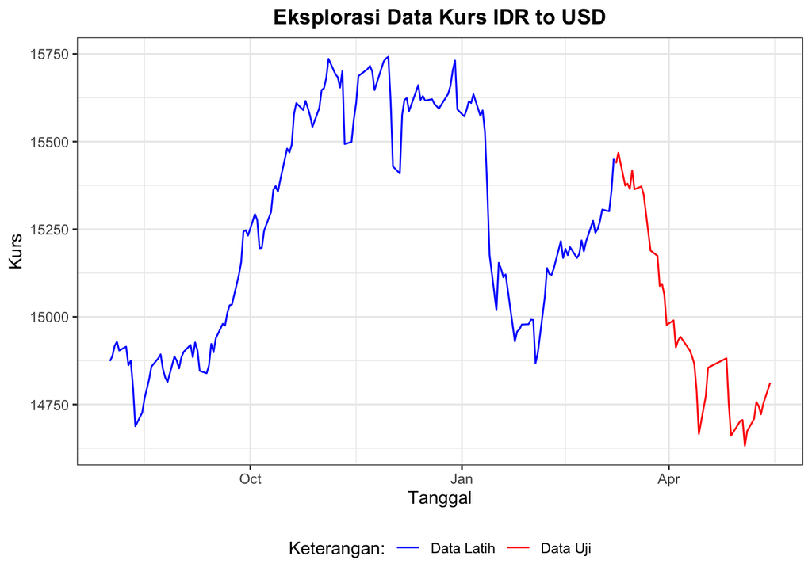

```r
ggplot() +
  geom_line(data = training_ma, aes(x = Tanggal, y = Kurs, col = "Data Latih")) +
  geom_line(data = testing_ma, aes(x = Tanggal, y = Kurs, col = "Data Uji")) +
  labs(title = "Eksplorasi Data Kurs IDR to USD", x = "Tanggal", y = "Kurs", color = "Keterangan:") +
  scale_colour_manual(values = c("Data Latih" = "blue", "Data Uji" = "red")) +
  theme_bw() +
  theme(legend.position = "bottom", plot.title = element_text(hjust = 0.5, face = "bold"))
```

## Single Moving Average (SMA)

Metode Single Moving Average (SMA) memanfaatkan rata-rata bergerak dari $n$ periode terakhir untuk meratakan fluktuasi jangka pendek. Pada tahap ini digunakan nilai $n = 2$.

```r
# 1. Pemulusan SMA (n = 2)
data.sma <- SMA(train_ma.ts, n = 2)

# 2. Peramalan 1 periode ke depan untuk data latih
data.ramal.sma <- c(NA, data.sma)
```

Selanjutnya dilakukan peramalan untuk periode data uji. Pada metode SMA, nilai ramalan untuk seluruh $h$-periode ke depan pada data uji bersifat konstan (konstanta horizontal), yaitu mengacu pada nilai hasil pemulusan terakhir dari data latih.

```r
# 3. Peramalan 39 periode ke depan untuk data uji
n_test <- length(test_ma.ts)
ramalan_sma_test <- rep(data.ramal.sma[length(data.ramal.sma)], n_test)
```

Seluruh komponen (data aktual, pemulusan, dan hasil peramalan) digabungkan ke dalam satu matriks/data frame untuk mempermudah plotting dan evaluasi kesalahan.

```r
# 4. Penggabungan Data (Total 195 observasi)
data.gab.sma <- cbind(
  aktual    = c(data.ts),
  pemulusan = c(data.sma, rep(NA, n_test)),
  ramalan   = c(data.ramal.sma, ramalan_sma_test[-1])
)
```

Grafik berikut menampilkan perbandingan antara data aktual, kurva pemulusan SMA ($n=2$), dan garis peramalan pada data uji.

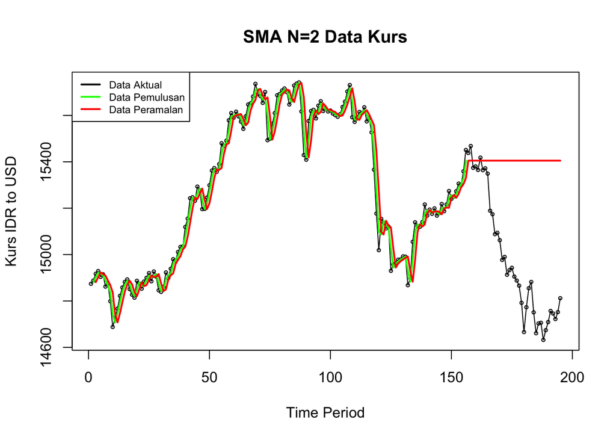

```r
# 5. Visualisasi Plot SMA
ts.plot(data.ts, xlab = "Time Period", ylab = "Kurs IDR to USD", main = "SMA N=2 Data Kurs")
points(data.ts, cex = 0.5)
lines(data.gab.sma[, "pemulusan"], col = "green", lwd = 2)
lines(data.gab.sma[, "ramalan"], col = "red", lwd = 2)
legend("topleft", legend = c("Data Aktual", "Data Pemulusan", "Data Peramalan"),
       col = c("black", "green", "red"), lty = 1, lwd = 2, cex = 0.7)
```

Langkah terakhir untuk metode SMA adalah mengukur tingkat akurasi pemodelan pada data latih maupun data uji menggunakan kriteria matriks galat (SSE, MSE, dan MAPE).

```r
# 6. Akurasi Data Latih
error_train.sma  <- train_ma.ts - data.ramal.sma[1:n_train]
SSE_train.sma    <- sum(error_train.sma[3:n_train]^2, na.rm = TRUE)
MSE_train.sma    <- mean(error_train.sma[3:n_train]^2, na.rm = TRUE)
MAPE_train.sma   <- mean(abs(error_train.sma[3:n_train] / train_ma.ts[3:n_train]) * 100, na.rm = TRUE)

akurasi_train.sma <- matrix(c(SSE_train.sma, MSE_train.sma, MAPE_train.sma),
                            dimnames = list(c("SSE", "MSE", "MAPE (%)"), "Akurasi Train (n=2)"))

# 7. Akurasi Data Uji
error_test.sma  <- test_ma.ts - data.gab.sma[(n_train + 1):n, "ramalan"]
SSE_test.sma    <- sum(error_test.sma^2)
MSE_test.sma    <- mean(error_test.sma^2)
MAPE_test.sma   <- mean(abs(error_test.sma / test_ma.ts) * 100)

akurasi_test.sma <- matrix(c(SSE_test.sma, MSE_test.sma, MAPE_test.sma),
                           dimnames = list(c("SSE", "MSE", "MAPE (%)"), "Akurasi Test (n=2)"))

# Tampilkan Tabel Akurasi SMA
cbind(akurasi_train.sma, akurasi_test.sma)
```

```
##          Akurasi Train (n=2) Akurasi Test (n=2)
## SSE             7.733962e+05       9.845744e+06
## MSE             5.022054e+03       2.524550e+05
## MAPE (%)        3.264059e-01       2.918713e+00
```

Hasil evaluasi akurasi menunjukkan bahwa model SMA ($n=2$) menghasilkan nilai galat yang sangat kecil pada data latih dengan nilai MAPE sebesar 0.3264% (MSE = 5.022054e+03), yang menandakan bahwa pemulusan mampu memfit data historis dengan sangat presisi karena penggunaan periode rata-rata yang singkat. Namun, ketika dievaluasi pada data uji, nilai galat meningkat signifikan dengan MAPE sebesar 2.9187% dan MSE membengkak menjadi 2.524550e+05 (SSE = 9.845744e+06). Peningkatan galat yang drastis pada data uji ini terjadi karena SMA meramalkan nilai konstan mendatar (flat forecast) berdasarkan rata-rata 2 periode terakhir data latih, sehingga tidak mampu mengantisipasi perubahan tren penurunan (downward trend) yang terjadi secara nyata pada periode data uji.

## Double Moving Average (DMA)

Metode Double Moving Average (DMA) dirancang khusus untuk mengatasi kelemahan SMA pada data yang memiliki komponen tren linear. Pemulusan dilakukan dua tahap (pemulusan atas hasil pemulusan pertama) untuk menghitung komponen intercept ($A_t$) dan slope ($B_t$).

```r
# 1. Pemulusan Tahap II & Komponen At, Bt (n = 2)
dma <- SMA(data.sma, n = 2)
At  <- 2 * data.sma - dma
Bt  <- (2 / (2 - 1)) * (data.sma - dma)

# 2. Pemulusan & Fitting Data Latih
data.dma <- At + Bt
data.ramal.dma <- c(NA, data.dma)
```

Peramalan $h$-periode ke depan untuk data uji dihitung secara dinamis mengikuti persamaan tren linier: $F_{t+h} = A_t + B_t \times h$.

```r
# 3. Peramalan 39 periode ke depan untuk data uji
n_test <- length(test_ma.ts)
f_dma  <- numeric(n_test)
At_last <- At[length(At)]
Bt_last <- Bt[length(Bt)]

for (h in 1:n_test) {
  f_dma[h] <- At_last + Bt_last * h
}
```

Selanjutnya, hasil kalkulasi disatukan dalam satu matriks gabungan untuk plotting dan evaluasi galat.

```r
# 4. Penggabungan Data (Total 195 observasi)
data.gab.dma <- cbind(
  aktual     = c(data.ts),
  pemulusan1 = c(data.sma, rep(NA, n_test)),
  pemulusan2 = c(dma, rep(NA, n_test)),
  At         = c(At, rep(NA, n_test)),
  Bt         = c(Bt, rep(NA, n_test)),
  ramalan    = c(data.ramal.dma, f_dma[-1])
)
```

Grafik berikut menampilkan perbandingan data aktual dengan hasil pemulusan serta lintasan garis peramalan DMA.

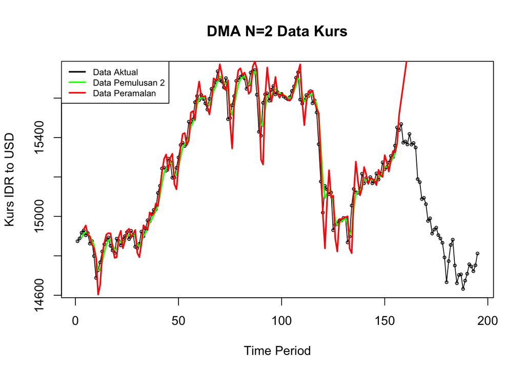

```r
# 5. Visualisasi Plot DMA
ts.plot(data.ts, xlab = "Time Period", ylab = "Kurs IDR to USD", main = "DMA N=2 Data Kurs")
points(data.ts, cex = 0.5)
lines(data.gab.dma[, "pemulusan2"], col = "green", lwd = 2)
lines(data.gab.dma[, "ramalan"], col = "red", lwd = 2)
legend("topleft", legend = c("Data Aktual", "Data Pemulusan 2", "Data Peramalan"),
       col = c("black", "green", "red"), lty = 1, lwd = 2, cex = 0.7)
```

Perhitungan matriks akurasi galat untuk metode DMA dievaluasi pada data latih (mulai indeks ke-4 karena adanya lag pemulusan ganda) dan data uji.

```r
# 6. Akurasi Data Latih (Evaluasi dimulai dari indeks n=4)
error_train.dma  <- train_ma.ts - data.ramal.dma[1:n_train]
SSE_train.dma    <- sum(error_train.dma[4:n_train]^2, na.rm = TRUE)
MSE_train.dma    <- mean(error_train.dma[4:n_train]^2, na.rm = TRUE)
MAPE_train.dma   <- mean(abs(error_train.dma[4:n_train] / train_ma.ts[4:n_train]) * 100, na.rm = TRUE)

akurasi_train.dma <- matrix(c(SSE_train.dma, MSE_train.dma, MAPE_train.dma),
                            dimnames = list(c("SSE", "MSE", "MAPE (%)"), "Akurasi Train (n=2)"))

# 7. Akurasi Data Uji
error_test.dma  <- test_ma.ts - data.gab.dma[(n_train + 1):n, "ramalan"]
SSE_test.dma    <- sum(error_test.dma^2)
MSE_test.dma    <- mean(error_test.dma^2)
MAPE_test.dma   <- mean(abs(error_test.dma / test_ma.ts) * 100)

akurasi_test.dma <- matrix(c(SSE_test.dma, MSE_test.dma, MAPE_test.dma),
                           dimnames = list(c("SSE", "MSE", "MAPE (%)"), "Akurasi Test (n=2)"))

# Tampilkan Tabel Akurasi DMA
cbind(akurasi_train.dma, akurasi_test.dma)
```

```
##          Akurasi Train (n=2) Akurasi Test (n=2)
## SSE             9.302449e+05       1.971924e+08
## MSE             6.080032e+03       5.056215e+06
## MAPE (%)        3.568080e-01       1.324241e+01
```

Hasil evaluasi akurasi menunjukkan bahwa metode DMA ($n=2$) memberikan kinerja yang sangat baik pada data latih dengan nilai MAPE sebesar 0.3568% (MSE = 6.080032e+03), menandakan tingkat penyesuaian (fitting) yang sangat tinggi terhadap fluktuasi historis. Akan tetapi, pada data uji, nilai galat melonjak drastis dengan MAPE mencapai 13.2424% dan MSE sebesar 5.056215e+06 (SSE = 1.971924e+08). Lonjakan galat yang signifikan ini terjadi karena proyeksi tren linier DMA sangat sensitif terhadap kemiringan (slope) pada ujung periode data latih; ketika data uji justru berbalik arah mengalami tren penurunan (downward trend) yang kontras, garis peramalan linier DMA yang kaku menghasilkan deviasi yang semakin membesar di setiap periodenya.

## Single Exponential Smoothing (SES)

Metode Single Exponential Smoothing (SES) cocok untuk data stasioner tanpa pola tren atau musiman yang kuat, di mana bobot pengamatan menurun secara eksponensial. Dibandingkan dengan variasi parameter uji ($\alpha = 0.2$ dan $\alpha = 0.7$), digunakan pula pencarian parameter $\alpha$ optimal secara otomatis (SSE minimization).

```r
# 1. Pemulusan SES (alpha=0.2, alpha=0.7, dan alpha Optimum)
ses.1   <- HoltWinters(train_ma.ts, gamma = FALSE, beta = FALSE, alpha = 0.2)
ses.2   <- HoltWinters(train_ma.ts, gamma = FALSE, beta = FALSE, alpha = 0.7)
ses.opt <- HoltWinters(train_ma.ts, gamma = FALSE, beta = FALSE, alpha = NULL)
```

Proyeksi 39 periode ke depan dihitung untuk masing-masing nilai $\alpha$.

```r
# 2. Peramalan 39 periode ke depan untuk Data Uji
ramalan_ses1   <- forecast(ses.1, h = n_test)
ramalan_ses2   <- forecast(ses.2, h = n_test)
ramalan_sesopt <- forecast(ses.opt, h = n_test)
```

Grafik di bawah ini menggambarkan kurva fitted values dari nilai $\alpha$ optimum beserta batas peramalan pada data uji.

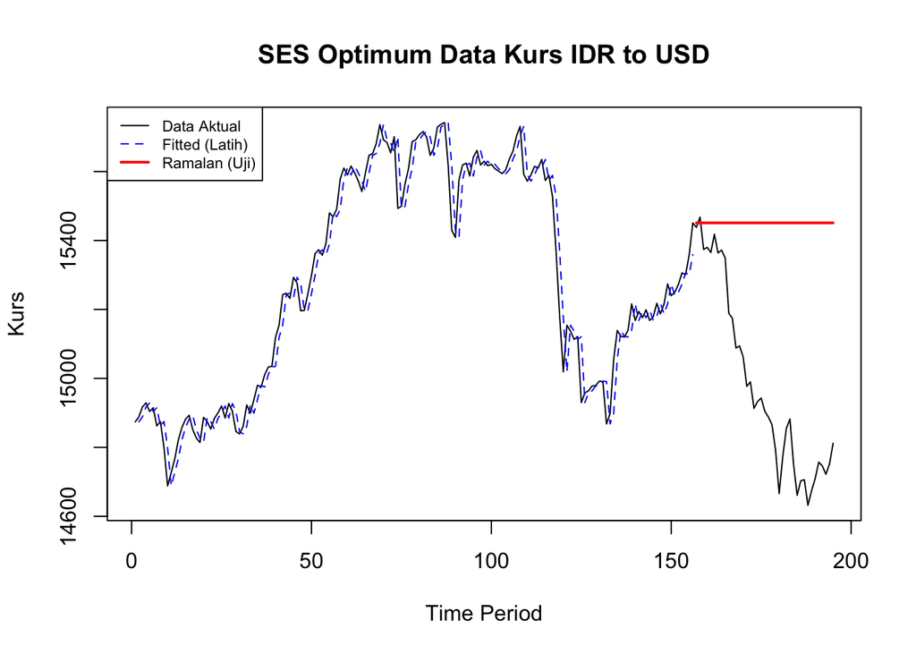

```r
# 3. Visualisasi Hasil Pemulusan & Peramalan SES Optimum
plot(data.ts, main = "SES Optimum Data Kurs IDR to USD", xlab = "Time Period", ylab = "Kurs")
lines(ses.opt$fitted[, 1], col = "blue", lty = 2)
lines(ramalan_sesopt$mean, col = "red", lwd = 2)
legend("topleft", legend = c("Data Aktual", "Fitted (Latih)", "Ramalan (Uji)"),
       col = c("black", "blue", "red"), lty = c(1, 2, 1), lwd = c(1, 1, 2), cex = 0.7)
```

Pemeriksaan ukuran pemodelan galat dilakukan secara komparatif antara $\alpha = 0.2$, $\alpha = 0.7$, dan $\alpha$ optimum pada data latih serta data uji.

```r
# 4. Akurasi Data Latih (Manual)
# alpha = 0.2
sisaan_ses1 <- ramalan_ses1$residuals
SSE_train.ses1  <- sum(sisaan_ses1[2:n_train]^2, na.rm = TRUE)
MSE_train.ses1  <- SSE_train.ses1 / n_train
RMSE_train.ses1 <- sqrt(MSE_train.ses1)
MAPE_train.ses1 <- mean(abs(sisaan_ses1[2:n_train] / train_ma.ts[2:n_train]) * 100, na.rm = TRUE)

# alpha = 0.7
sisaan_ses2 <- ramalan_ses2$residuals
SSE_train.ses2  <- sum(sisaan_ses2[2:n_train]^2, na.rm = TRUE)
MSE_train.ses2  <- SSE_train.ses2 / n_train
RMSE_train.ses2 <- sqrt(MSE_train.ses2)
MAPE_train.ses2 <- mean(abs(sisaan_ses2[2:n_train] / train_ma.ts[2:n_train]) * 100, na.rm = TRUE)

# alpha Optimum
sisaan_sesopt <- ramalan_sesopt$residuals
SSE_train.sesopt  <- sum(sisaan_sesopt[2:n_train]^2, na.rm = TRUE)
MSE_train.sesopt  <- SSE_train.sesopt / n_train
RMSE_train.sesopt <- sqrt(MSE_train.sesopt)
MAPE_train.sesopt <- mean(abs(sisaan_sesopt[2:n_train] / train_ma.ts[2:n_train]) * 100, na.rm = TRUE)

akurasi_train.ses <- matrix(
  c(SSE_train.ses1, MSE_train.ses1, RMSE_train.ses1, MAPE_train.ses1,
    SSE_train.ses2, MSE_train.ses2, RMSE_train.ses2, MAPE_train.ses2,
    SSE_train.sesopt, MSE_train.sesopt, RMSE_train.sesopt, MAPE_train.sesopt),
  nrow = 4, ncol = 3,
  dimnames = list(c("SSE", "MSE", "RMSE", "MAPE (%)"), c("SES (a=0.2)", "SES (a=0.7)", "SES (Opt)"))
)

# 5. Akurasi Data Uji (Manual)
selisih_ses1   <- as.numeric(ramalan_ses1$mean) - as.numeric(test_ma.ts)
selisih_ses2   <- as.numeric(ramalan_ses2$mean) - as.numeric(test_ma.ts)
selisih_sesopt <- as.numeric(ramalan_sesopt$mean) - as.numeric(test_ma.ts)

SSE_test.ses1  <- sum(selisih_ses1^2)
MSE_test.ses1  <- mean(selisih_ses1^2)
RMSE_test.ses1 <- sqrt(MSE_test.ses1)
MAPE_test.ses1 <- mean(abs(selisih_ses1 / test_ma.ts) * 100)

SSE_test.ses2  <- sum(selisih_ses2^2)
MSE_test.ses2  <- mean(selisih_ses2^2)
RMSE_test.ses2 <- sqrt(MSE_test.ses2)
MAPE_test.ses2 <- mean(abs(selisih_ses2 / test_ma.ts) * 100)

SSE_test.sesopt  <- sum(selisih_sesopt^2)
MSE_test.sesopt  <- mean(selisih_sesopt^2)
RMSE_test.sesopt <- sqrt(MSE_test.sesopt)
MAPE_test.sesopt <- mean(abs(selisih_sesopt / test_ma.ts) * 100)

akurasi_test.ses <- matrix(
  c(SSE_test.ses1, MSE_test.ses1, RMSE_test.ses1, MAPE_test.ses1,
    SSE_test.ses2, MSE_test.ses2, RMSE_test.ses2, MAPE_test.ses2,
    SSE_test.sesopt, MSE_test.sesopt, RMSE_test.sesopt, MAPE_test.sesopt),
  nrow = 4, ncol = 3,
  dimnames = list(c("SSE", "MSE", "RMSE", "MAPE (%)"), c("SES (a=0.2)", "SES (a=0.7)", "SES (Opt)"))
)

# Tampilkan Hasil Akurasi
list(`Akurasi Data Latih SES` = akurasi_train.ses, `Akurasi Data Uji SES` = akurasi_test.ses)
```

```
## $`Akurasi Data Latih SES`
##           SES (a=0.2)  SES (a=0.7)    SES (Opt)
## SSE      1.751673e+06 6.457615e+05 5.393612e+05
## MSE      1.122867e+04 4.139497e+03 3.457443e+03
## RMSE     1.059654e+02 6.433892e+01 5.880003e+01
## MAPE (%) 5.183037e-01 2.923036e-01 2.703483e-01
##
## $`Akurasi Data Uji SES`
##           SES (a=0.2)  SES (a=0.7)    SES (Opt)
## SSE      7.060318e+06 1.028486e+07 1.146005e+07
## MSE      1.810338e+05 2.637145e+05 2.938474e+05
## RMSE     4.254807e+02 5.135314e+02 5.420769e+02
## MAPE (%) 2.497446e+00 2.992512e+00 3.195353e+00
```

Pada data latih, kinerja pemulusan SES meningkat seiring membesarnya nilai $\alpha$, di mana SES Optimum membuahkan hasil terbaik dengan galat terkecil (MAPE = 0.2703%, MSE = 3.457443e+03) karena nilai $\alpha$ yang tinggi memberikan bobot lebih besar pada pengamatan terbaru. Sebaliknya pada data uji, skenario SES ($\alpha = 0.2$) justru menghasilkan akurasi peramalan terbaik dengan nilai galat paling rendah (MAPE = 2.4974%, MSE = 1.810338e+05, RMSE = 425.48) dibandingkan SES ($\alpha = 0.7$) maupun SES Optimum. Pola ini menunjukkan bahwa pada peramalan jarak jauh $h$-periode ke depan yang menghasilkan garis ramalan mendatar (flat forecast), parameter $\alpha$ yang lebih stabil/rendah ($\alpha=0.2$) menahan proyeksi pada level rata-rata yang lebih proporsional terhadap tren penurunan data uji, sehingga terhindar dari overfitting pada titik puncak akhir data latih.

## Double Exponential Smoothing (DES)

Metode Double Exponential Smoothing (DES / Holt’s Method) mengakomodasi pemulusan tingkat (level, $\alpha$) sekaligus tren (slope, $\beta$). Tiga skenario dicoba: Skenario 1 ($\alpha=0.2, \beta=0.2$), Skenario 2 ($\alpha=0.6, \beta=0.3$), dan DES dengan pencarian parameter optimal secara otomatis.

```r
# 1. Pemulusan DES (Skenario 1, Skenario 2, dan Optimum)
des.1   <- HoltWinters(train_ma.ts, gamma = FALSE, beta = 0.2, alpha = 0.2)
des.2   <- HoltWinters(train_ma.ts, gamma = FALSE, beta = 0.3, alpha = 0.6)
des.opt <- HoltWinters(train_ma.ts, gamma = FALSE, beta = NULL, alpha = NULL)
```

Pemodelan dilanjutkan dengan meramal 39 periode data uji dari masing-masing skenario DES.

```r
# 2. Peramalan 39 periode ke depan untuk Data Uji
ramalan_des1   <- forecast(des.1, h = n_test)
ramalan_des2   <- forecast(des.2, h = n_test)
ramalan_desopt <- forecast(des.opt, h = n_test)
```

Plot berikut menyajikan kesesuaian model DES Optimum pada data latih serta lintasan peramalan tren pada data uji.

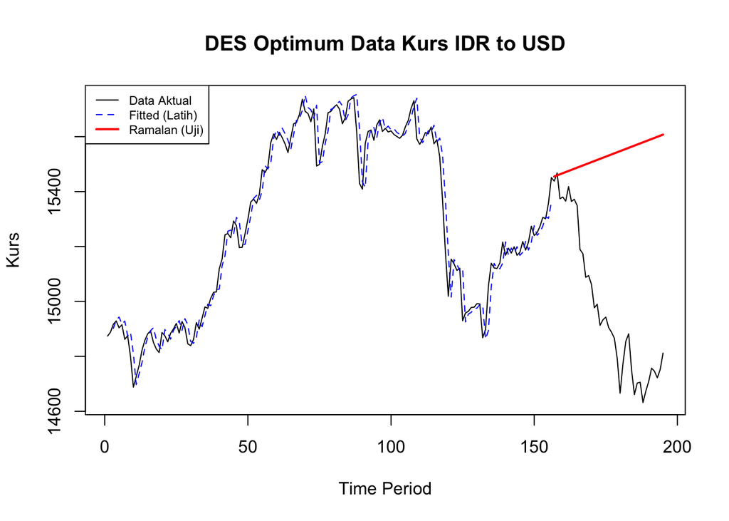

```r
# 3. Visualisasi Hasil Pemulusan & Peramalan DES Optimum
plot(data.ts, main = "DES Optimum Data Kurs IDR to USD", xlab = "Time Period", ylab = "Kurs")
lines(des.opt$fitted[, 1], col = "blue", lty = 2)
lines(ramalan_desopt$mean, col = "red", lwd = 2)
legend("topleft", legend = c("Data Aktual", "Fitted (Latih)", "Ramalan (Uji)"),
       col = c("black", "blue", "red"), lty = c(1, 2, 1), lwd = c(1, 1, 2), cex = 0.7)
```

Ukuran kebaikan model (SSE, MSE, RMSE, MAPE) dihitung untuk data latih dan data uji pada ketiga skenario DES.

```r
# 4. Akurasi Data Latih (Manual)
# Skenario 1 (a=0.2, b=0.2)
sisaan_des1 <- ramalan_des1$residuals
SSE_train.des1  <- sum(sisaan_des1[3:n_train]^2, na.rm = TRUE)
MSE_train.des1  <- SSE_train.des1 / n_train
RMSE_train.des1 <- sqrt(MSE_train.des1)
MAPE_train.des1 <- mean(abs(sisaan_des1[3:n_train] / train_ma.ts[3:n_train]) * 100, na.rm = TRUE)

# Skenario 2 (a=0.6, b=0.3)
sisaan_des2 <- ramalan_des2$residuals
SSE_train.des2  <- sum(sisaan_des2[3:n_train]^2, na.rm = TRUE)
MSE_train.des2  <- SSE_train.des2 / n_train
RMSE_train.des2 <- sqrt(MSE_train.des2)
MAPE_train.des2 <- mean(abs(sisaan_des2[3:n_train] / train_ma.ts[3:n_train]) * 100, na.rm = TRUE)

# DES Optimum
sisaan_desopt <- ramalan_desopt$residuals
SSE_train.desopt  <- sum(sisaan_desopt[3:n_train]^2, na.rm = TRUE)
MSE_train.desopt  <- SSE_train.desopt / n_train
RMSE_train.desopt <- sqrt(MSE_train.desopt)
MAPE_train.desopt <- mean(abs(sisaan_desopt[3:n_train] / train_ma.ts[3:n_train]) * 100, na.rm = TRUE)

akurasi_train.des <- matrix(
  c(SSE_train.des1, MSE_train.des1, RMSE_train.des1, MAPE_train.des1,
    SSE_train.des2, MSE_train.des2, RMSE_train.des2, MAPE_train.des2,
    SSE_train.desopt, MSE_train.desopt, RMSE_train.desopt, MAPE_train.desopt),
  nrow = 4, ncol = 3,
  dimnames = list(c("SSE", "MSE", "RMSE", "MAPE (%)"), c("DES (Ske 1)", "DES (Ske 2)", "DES (Opt)"))
)

# 5. Akurasi Data Uji (Manual)
selisih_des1   <- as.numeric(ramalan_des1$mean) - as.numeric(test_ma.ts)
selisih_des2   <- as.numeric(ramalan_des2$mean) - as.numeric(test_ma.ts)
selisih_desopt <- as.numeric(ramalan_desopt$mean) - as.numeric(test_ma.ts)

SSE_test.des1  <- sum(selisih_des1^2)
MSE_test.des1  <- mean(selisih_des1^2)
RMSE_test.des1 <- sqrt(MSE_test.des1)
MAPE_test.des1 <- mean(abs(selisih_des1 / test_ma.ts) * 100)

SSE_test.des2  <- sum(selisih_des2^2)
MSE_test.des2  <- mean(selisih_des2^2)
RMSE_test.des2 <- sqrt(MSE_test.des2)
MAPE_test.des2 <- mean(abs(selisih_des2 / test_ma.ts) * 100)

SSE_test.desopt  <- sum(selisih_desopt^2)
MSE_test.desopt  <- mean(selisih_desopt^2)
RMSE_test.desopt <- sqrt(MSE_test.desopt)
MAPE_test.desopt <- mean(abs(selisih_desopt / test_ma.ts) * 100)

akurasi_test.des <- matrix(
  c(SSE_test.des1, MSE_test.des1, RMSE_test.des1, MAPE_test.des1,
    SSE_test.des2, MSE_test.des2, RMSE_test.des2, MAPE_test.des2,
    SSE_test.desopt, MSE_test.desopt, RMSE_test.desopt, MAPE_test.desopt),
  nrow = 4, ncol = 3,
  dimnames = list(c("SSE", "MSE", "RMSE", "MAPE (%)"), c("DES (Ske 1)", "DES (Ske 2)", "DES (Opt)"))
)

# Tampilkan Hasil Akurasi
list(`Akurasi Data Latih DES` = akurasi_train.des, `Akurasi Data Uji DES` = akurasi_test.des)
```

```
## $`Akurasi Data Latih DES`
##           DES (Ske 1)  DES (Ske 2)    DES (Opt)
## SSE      1.503474e+06 7.545851e+05 5.449682e+05
## MSE      9.637656e+03 4.837084e+03 3.493386e+03
## RMSE     9.817156e+01 6.954915e+01 5.910487e+01
## MAPE (%) 4.600990e-01 3.379895e-01 2.676013e-01
##
## $`Akurasi Data Uji DES`
##           DES (Ske 1)  DES (Ske 2)    DES (Opt)
## SSE      2.657338e+07 7.064295e+07 1.561381e+07
## MSE      6.813688e+05 1.811358e+06 4.003540e+05
## RMSE     8.254507e+02 1.345867e+03 6.327353e+02
## MAPE (%) 4.779861e+00 7.890610e+00 3.733296e+00
```

Pada data latih, skenario DES Optimum menunjukkan performa pemodelan terbaik dengan tingkat galat paling rendah (MAPE = 0.2676%, MSE = 3.493386e+03, RMSE = 59.10) karena kombinasi parameter $\alpha$ dan $\beta$ berhasil disesuaikan secara otomatis untuk memfit pola level dan tren historis. Keunggulan DES Optimum ini konsisten berlanjut pada data uji dengan menghasilkan akurasi peramalan tertinggi dibanding skenario lainnya, dicirikan oleh nilai galat paling minimum (MAPE = 3.7333%, MSE = 4.003540e+05, RMSE = 632.74). Meskipun nilai MAPE pada data uji meningkat dibanding data latih akibat proyeksi tren linear yang kaku di tengah perubahan arah kurs, DES Optimum tetap terbukti lebih handal dan adaptif mengontrol penyimpangan ramalan dibandingkan skenario manual DES Skenario 1 ($\alpha=0.2, \beta=0.2$) maupun Skenario 2 ($\alpha=0.6, \beta=0.3$).

## Holt-Winters

Metode Holt-Winters digunakan apabila data memiliki komponen level, tren, sekaligus pola musiman (seasonal). Pada chunk ini, dibuat struktur data time series dengan frekuensi musiman buatan $frequency = 5$ (misalnya diasumsikan siklus 5 harian/mingguan). Dipisahkan antara pendekatan aditif (additive) dan multiplikatif (multiplicative).

```r
# 1. Penyiapan Time Series Berfrekuensi Musiman
train_hw.ts <- ts(training_ma$Kurs, frequency = 5)
test_hw.ts  <- ts(testing_ma$Kurs, frequency = 5)

# 2. Pemulusan Holt-Winters Aditif & Multiplikatif (Optimum)
hw_add.opt  <- HoltWinters(train_hw.ts, seasonal = "additive")
hw_mult.opt <- HoltWinters(train_hw.ts, seasonal = "multiplicative")
```

Peramalan untuk 39 periode dilakukan berdasarkan estimasi parameter Holt-Winters aditif dan multiplikatif.

```r
# 3. Peramalan 39 periode ke depan
ramalan_hw_add  <- forecast(hw_add.opt, h = n_test)
ramalan_hw_mult <- forecast(hw_mult.opt, h = n_test)
```

Langkah berikutnya adalah menghitung indikator ukuran kebaikan pemodelan galat Holt-Winters pada data uji.

```r
# 4. Akurasi Data Uji Holt-Winters
selisih_hw_add  <- as.numeric(ramalan_hw_add$mean) - as.numeric(test_hw.ts)
selisih_hw_mult <- as.numeric(ramalan_hw_mult$mean) - as.numeric(test_hw.ts)

SSE_test.hw_add  <- sum(selisih_hw_add^2)
MSE_test.hw_add  <- mean(selisih_hw_add^2)
RMSE_test.hw_add <- sqrt(MSE_test.hw_add)
MAPE_test.hw_add <- mean(abs(selisih_hw_add / test_hw.ts) * 100)

SSE_test.hw_mult  <- sum(selisih_hw_mult^2)
MSE_test.hw_mult  <- mean(selisih_hw_mult^2)
RMSE_test.hw_mult <- sqrt(MSE_test.hw_mult)
MAPE_test.hw_mult <- mean(abs(selisih_hw_mult / test_hw.ts) * 100)

akurasi_test.hw <- matrix(
  c(SSE_test.hw_add, MSE_test.hw_add, RMSE_test.hw_add, MAPE_test.hw_add,
    SSE_test.hw_mult, MSE_test.hw_mult, RMSE_test.hw_mult, MAPE_test.hw_mult),
  nrow = 4, ncol = 2,
  dimnames = list(c("SSE", "MSE", "RMSE", "MAPE (%)"), c("HW Aditif Opt", "HW Multiplikatif Opt"))
)

# Tampilkan Hasil Akurasi Data Uji Holt-Winters
akurasi_test.hw
```

```
##          HW Aditif Opt HW Multiplikatif Opt
## SSE       2.110995e+07         2.091063e+07
## MSE       5.412809e+05         5.361700e+05
## RMSE      7.357179e+02         7.322363e+02
## MAPE (%)  4.323680e+00         4.302580e+00
```

Hasil evaluasi akurasi pada data uji menunjukkan bahwa Holt-Winters Multiplikatif Optimum memberikan kinerja peramalan yang sedikit lebih presisi dibandingkan dengan Holt-Winters Aditif Optimum. Metode multiplikatif menghasilkan nilai galat yang lebih rendah di seluruh indikator evaluasi dengan MAPE sebesar 4.3026% (MSE = 5.361700e+05, RMSE = 732.24) berbanding 4.3237% pada metode aditif. Keunggulan tipis pada pendekatan multiplikatif ini mengindikasikan bahwa variasi fluktuasi musiman buatan ($frequency = 5$) pada data kurs cenderung berubah secara proporsional mengikuti perubahan tingkat level data, meskipun secara umum kedua model memberikan estimasi akurasi yang relatif seimbang pada kisaran MAPE 4.3%.

## Perbandingan Seluruh Metode Pemulusan

```r
# Penggabungan nilai akurasi data uji dari metode terbaik masing-masing
perbandingan_semua <- data.frame(
  Metode = c("SMA (n=2)", "DMA (n=2)", "SES Optimum", "DES Optimum", "Holt-Winters Aditif Opt"),
  SSE  = c(SSE_test.sma, SSE_test.dma, SSE_test.sesopt, SSE_test.desopt, SSE_test.hw_add),
  MSE  = c(MSE_test.sma, MSE_test.dma, MSE_test.sesopt, MSE_test.desopt, MSE_test.hw_add),
  RMSE = c(sqrt(MSE_test.sma), sqrt(MSE_test.dma), RMSE_test.sesopt, RMSE_test.desopt, RMSE_test.hw_add),
  `MAPE (%)` = c(MAPE_test.sma, MAPE_test.dma, MAPE_test.sesopt, MAPE_test.desopt, MAPE_test.hw_add),
  check.names = FALSE
)

knitr::kable(perbandingan_semua, digits = 4, caption = "Ringkasan Perbandingan Akurasi Data Uji Seluruh Metode")
```

Ringkasan Perbandingan Akurasi Data Uji Seluruh Metode

| Metode | SSE | MSE | RMSE | MAPE (%) |
| --- | --- | --- | --- | --- |
| SMA (n=2) | 9845744 | 252455.0 | 502.4490 | 2.9187 |
| DMA (n=2) | 197192388 | 5056215.1 | 2248.6029 | 13.2424 |
| SES Optimum | 11460049 | 293847.4 | 542.0769 | 3.1954 |
| DES Optimum | 15613807 | 400354.0 | 632.7353 | 3.7333 |
| Holt-Winters Aditif Opt | 21109953 | 541280.9 | 735.7179 | 4.3237 |